# QurvE App User Manual v.1.0

Nicolas T. Wirth and Stefano Donati

2022-12-20

*QurvE* is an R package for analyzing growth and fluorescence data measured over time. It features a graphical user interface (GUI) developed as a Shiny app, which has been designed to be user-friendly and intuitive. *QurvE* offers a variety of analysis tools to streamline the process of growth profiling and ensure reproducibility. It can also be used to characterize fluorescence data, such as in plate reader experiments for biosensor characterization. Overall, *QurvE* aims to make data analysis and reporting quick, efficient, and reliable.

# Navigation Bar

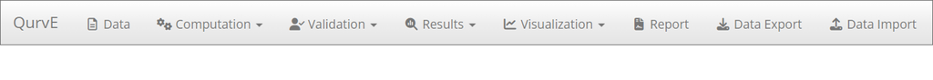

The QurvE navigation bar.

- *Data*: Load experimental data. Use either one of several available parsers for common cultivation devices or provide data in a custom format.
- *Computation:* Run computational workflows on entire growth or fluorescence datasets to perform curve fitting and dose-response analyses. This menu becomes available after successful data parsing.
- *Validation:* Confirm the accuracy of the fits for each sample and re-run individual fits with adjusted parameters.
- *Results:* View tabular summaries of computational results, including calculated growth and fluorescence curve parameters and results of dose-response analyses.
- *Visualization:* Compare samples and conditions and visualize computational results using a series of plots.
- *Report:* Create a PDF or HTML report summarizing all results from a growth or fluorescence curve analysis workflow.
- *Data Export*: Save raw data, all computational results, and fitting options as a .RData object for storage and distribution.
- *Data Import:* Load a previously exported dataset in .RData format.

# Loading Data

*QurvE* allows loading data in different formats, for both growth experiments and for fluorescence measurements. Data can be loaded by using the custom QurvE data layout, by loading raw data from various measuring equipment or by importing previously analyzed datasets.

## Loading data formatted in the custom QurvE layout

To load data using the custom QurvE layout, select the [Data] > [Custom] window and choose a file in .xls/.xlsx (selecting the appropriate work sheets) or .csv/.tsv/.txt format (define the correct decimal separator and, for .csv, field separator in the target file). The custom QurvE layout includes all data and relative metadata necessary for QurvE to perform the analysis. This custom layout can be used to load both growth and fluorescence data. Data from a second fluorescence channel can be used to normalize the primary fluorescence values in addition to normalization to growth values.

The data must be formatted as displayed in Figure @ref(fig:custom-layout):

- The first row contains ‘Time’, ‘Blank’, and the sample identifiers (IDs). The ID needs to be identical for replicates and for samples analyzed together within a dose-response analysis. The ‘Time’ column must be positioned at the first position, ‘Blank’ and the samples follow in arbitrary order.
- The second row contains replicate numbers for identical conditions. If technical replicates were used in addition to biological replicates, indicate technical replicates with identical replicate numbers. Samples with identical IDs, replicate numbers, and concentration values (if applicable) will be combined by their average values at each time point. Leave the row empty if no replicate information is available.
- The third row is designated to contain concentration values to perform a dose-response analysis, if different concentrations of a compound were used in the experiment. Samples are included in the same dose-response analysis if they have identical sample identifiers (first row). Leave the row empty if no concentration information is available or relevant.
- Starting with the fourth row, the table must include data for ‘Time’, ‘Blank’ and the different samples.

Several experiments can be combined into a single custom dataset. Different experiments with differing time values and experiment-specific blanks are distinguished by an individual ‘Time’ column to the left of each dataset. Blank values (experiment-specific) are combined as their average and subtracted from all remaining values if the option [Subtract blank] is selected. The metadata on the second and third row is optional to perform the analysis; if no such metadata is available, leave the rows empty.

The data can be further processed by (options indicated in the order in which they are applied to the data):

1. converting time values,
2. applying a calibration equation to measurements.
3. subtracting the blank values from each sample measurement,
4. normalizing fluorescence data with a second fluorescence or growth dataset, if available.

All these data processing functions are optional.

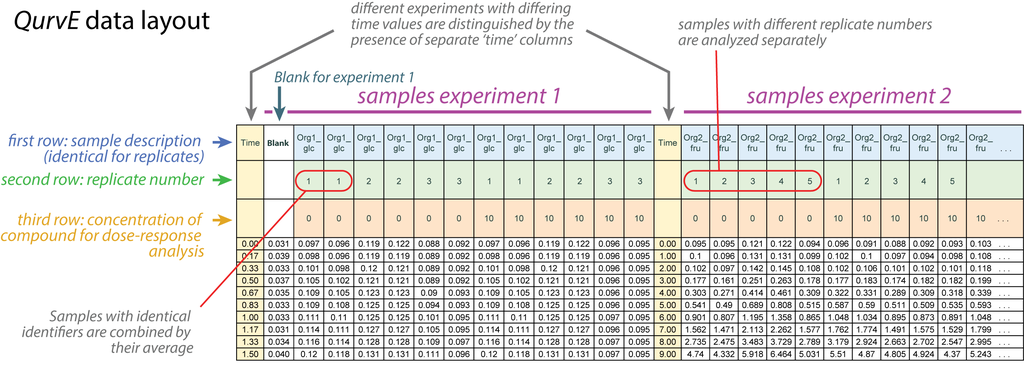

QurvE custom data layout.

## Loading data from raw experiment files

*QurvE* supports loading directly raw data produced by a variety of proprietary software for different growth or fluorescence measuring equipment, such as plate readers and micro-bioreactors[^1]. This can be done in the [Data] > [Parse Raw Data] window.

After loading the file (1), selecting the correct raw data format by choosing one of the available equipments/software (2) and assigning the extracted read channels to growth/fluorescence data (3), the user has to provide mapping information with metadata in tabular format (in a .xls/.xlsx/.csv/.tsv/.txt file) (4).

The mapping file should be formatted as shown in Figure @ref(fig:mapping-layout):

- The first column contains the well numbers in the plate and must match sample identifiers in the raw data file.
- The second column contains the ID (i.e., organism, condition, etc.) of each sample. The ID needs to be identical for replicates and for samples analyzed together within a dose-response analysis.
- The third column contains replicate numbers for identical conditions. If technical replicates were used in addition to biological replicates, indicate technical replicates with the same replicate number. Samples with identical IDs, replicate numbers, and concentration values (if applicable) will be combined by their average values at each time point. Leave the row empty if no replicate information is available.
- The fourth column is designated to contain concentration values to perform a dose-response analysis, if different concentrations of a compound of interest were used in the experiment. Leave the row empty if no additional concentration information is available.

The values in ‘Blank’ samples are combined by their averages and subtracted from all remaining values if the option [Subtract blank] is chosen.

The data can be further processed by (options indicated in the order in which they are applied to the data):

1. converting time values,
2. applying a calibration equation to measurements.
3. subtracting the blank values from each sample measurement,
4. normalizing fluorescence data with a second fluorescence or growth dataset, if available.

All these data processing functions are optional.

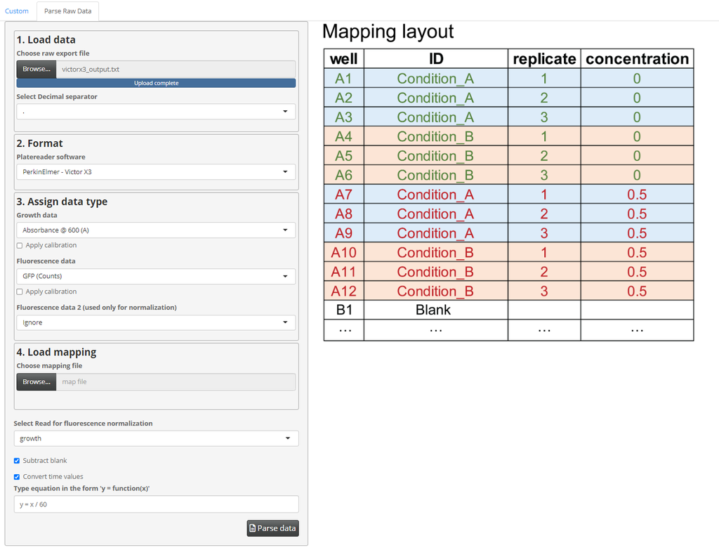

The [Parse Raw Data] window enables loading raw data exported from a plate reader/bioreactor software. The right panel illustrates the layout of the additional mapping file with metadata that must be supplemented to analyze establish relationships between conditions and replicates.

## Loading previously processed data

*QurvE* supports exporting processed data and reloading it for further analysis or inspection. Previously saved growth or fluorescence data in .RData format can be loaded in the Data Import window (Figure @ref(fig:import-data)).

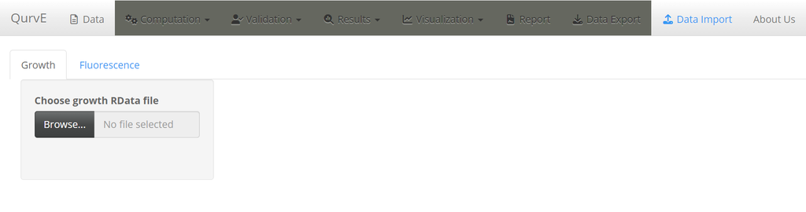

The figure illustrates the [Data Import] window, which enables the user to load previously exported QurvE data files.

# Processing and analyzing data in *QurvE*

Once raw data is loaded, *QurvE* can be used to process the data by fitting curves, calculating averages and standard deviations for replicates, as well as fitting the data with different models to obtain growth parameters such as doubling times, yields, etc., or dose-response parameters. Moreover, the software allows the user to intuitively create publication-grade plots.

## Run computations

Dose-response (EC50) analyses can be performed by either performing a smooth spline fit (response spline fit) on response vs. concentration data and extracting the *EC<sub>50</sub>* as the concentration at the midpoint between the largest and smallest response value, or by applying up to 20 (parametric) dose-response models to choose the best model based on the Akaike information criterion (AIC). Any computed parameter (e.g., growth rates obtained via linear regression, maximum fluorescence obtained via non-parametric fits…) can be chosen as response parameter to quantify adverse or beneficial effects of a substance. The options to Log-transform concentration or Log-transform response are only available for *response spline fits*. In both instances, Ln(x + 1) is applied to the respective values.

Additional information on all methods and (global or method-specific) fitting options is available by clicking on the [?] signs.

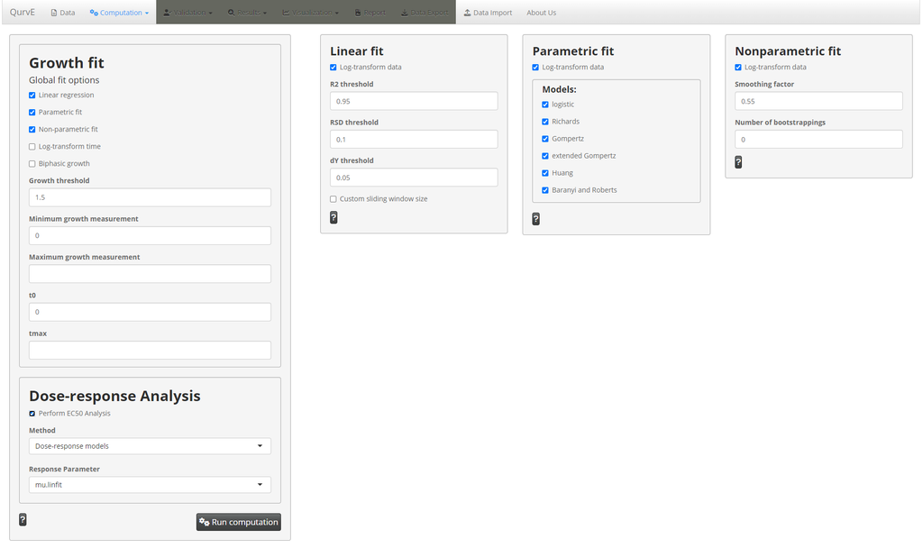

The [Computation] window enables the user to define parameters for data processing and fitting. Growth data and fluorescence data must be processed separately.

## Visualization and validation of curve fitting

The [Validation] window enables the user to verify the correct fitting of the growth/fluorescence curves (see Figure @ref(fig:linear) for an example).

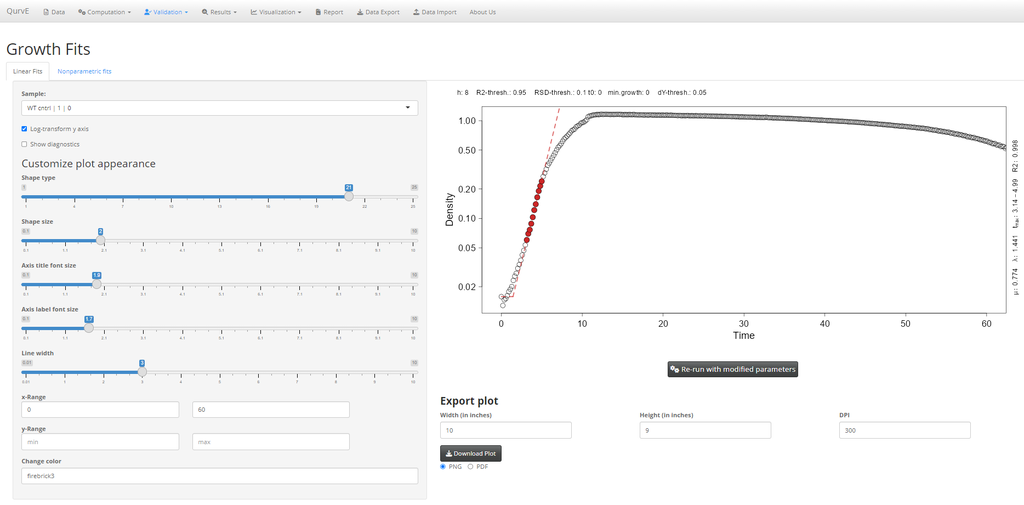

Example of a fitted growth curve in the [Validation] window. On the right panel, the figure visualizes the performed fit. In this case, the red dots and dashed line represent the linear regression model used to calculate the maximum growth rate and lag time.

Different tabs enable the user to visualize the fit obtained with different fitting methods (Linear Fits, Nonparametric fits, etc.). In the left pane the independent samples can be selected for visualization. It further contains options to modify the figure, which can be exported in .png or .pdf formats. In the right pane, the [Re-run with modified parameters] button enables the user to modify the fitting parameters and rerun the analysis only for the selected sample to obtain a new fit and updated parameters.

## Tabular overview of results

The [Results] window (see Figure @ref(fig:results)) enables the user to obtain an overview of the fitted parameters for each applied method. By ticking the [Group average] box the user can visualize the **average ± standard deviation** of parameters for replicates. If deselected, the parameters for every single sample are shown. The table can be exported in .csv format by clicking on the [Download table] button.

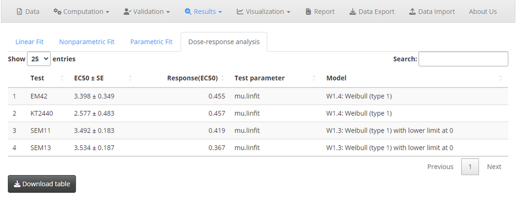

The [Results] window gives a tabular overview of all computed parameters for each applied fit method as well as the results dose-response analyses.

## Visualization of results

Once the data has been processed, the [Visualization] window enables the user to visualize the data using different plot formats:

- **Group Plots**: Plot growth data over time for multiple conditions on the same plot. The [Data type] drop down menu allows the user to define the type of data (raw data, smoothing splines, normalized fluorescence) to be visualized as a curve chart. The user can easily select with the cursor which samples/groups to plot in the [Conditions] input. Alternatively, by ticking [(De-)select samples based on string], the user can select or exclude samples by typing strings which include the name of the sample to be included/excluded. The [Plot group averages] box is be used to visualize either averages of replicates (± standard deviations) or the individual samples independently. Moreover, if concentration metadata was provided while loading the data, the user can (de-)select samples using these additional parameters. The left pane contains also various options to modify the figure, which can be exported in .png or .pdf formats.
- **Parameter Plots**: Plot calculated curve parameters (growth rates, lag times, yields, etc.) of different samples as a bar plot. The [Parameter] drop down menu allows the user to select the parameter to be plotted. Samples and conditions can be (de-)selected via the same methods described for Group Plots. The Plot group averages box can be used to visualize either averages (and *95% confidence intervals*) of groups or the individual samples independently.
- **Plot Grid**: Plot several curves in separate panels, coloring the background based on a chosen parameter in a heatmap-like fashion. The [Data type] drop down menu allows the user to define the type of data to be visualized as a curve chart. The [Parameter] drop down menu allows the user to select the parameter by which the panel backgrounds will be colored. Samples and conditions can be (de-)selected via the same methods described for Group Plots. If concentration metadata was provided while loading the data, the panels can be arranged in a matrix with one concentration per row by ticking [Sort by concentration].
- **Dose-Response Analysis**: Plot the results of dose-response analyses with the chosen response parameter on the y-axis and concentration values on the x-axis. The drawn line indicates the fit that was applied to the data.

# Export data from QurvE

*QurvE* enables the user to export data or results in different ways:

- **Download Plot**: all figures plotted within QurvE can be exported in .png or .pdf formats. Please note that the size of the exported plots differs from the figure diplayed within the app which is dependent on the size of the *QurvE* window. The size, aspect ratio and resolution of each exported plot can be adjusted with the dedicated [Width], [Height], and [DPI] fields
- **Report**: The [Report] window enables the user to export all the computational results and figures for each performed fit in a single report file in .pdf or .html format.
- **Data Export**: The [Data Export] window enables the user to export all processed raw data as well as computation results and fitting options as a single data container in .RData format. Please note that modifications to figures are not included in the exported .RData file, so make sure to export your figures separately.

*In the spirit of good scientific practice (data transparency), we encourage anyone using QurvE to attach the .RData file and generated reports to their publication.*

[^1]: If *QurvE* does not include a **data parser** for your device, yet, please open an issue at https://github.com/NicWir/QurvE/issues. We are continually working on adding support for more equipment and software.